# K-Means Clustering

Alex Garbiak dev@alexgarbiak.com

01 October, 2020

# 1 Theory

# 2 `R` Practice

We are managing a `portfolio` of investments that contains 200 assets. In this `portfolio` we measure the following features:

- Price-to-Earnings Ratio (“*PE*”), labelled $x1$ with $x1 \sim \mathcal{N}(3,\,1)$
- Price-to-Book Ratio (“*PB*”), labelled $x2$ with 65% of the assets following $\mathcal{N}(10,\,1)$ and the remaining 35% following $\mathcal{N}(4,\,1)$

We replicate this in `R` as follows:

```r
library(dplyr) # Data manipulation

set.seed(2019) # Fix result
portfolio <- data.frame(
  x1 = rnorm(200, 3, 1),
  x2 = scale(
    c(
      rnorm(70, 4, 1),
      rnorm(130, 10, 1)
    )
  )
)

glimpse(portfolio)
```

```
## Rows: 200
## Columns: 2
## $ x1 <dbl> 3.7385227, 2.4852395, 1.3598187, 3.9160368, 1.7325180, 3.7382478...
## $ x2 <dbl> -1.0194154, -1.3874510, -0.9330323, -1.7205781, -0.9932322, -1.5...
```

Here the `scale()` function scales each element in the result by subtracting the sample mean and dividing by the sample standard deviation.

Next we want to explore whether these 200 assets can be divided into two clusters which we will label arbitrarily `A` and `B` based on the two metrics we have measured, PE (as $x1$) and PB (as $x2$).

We will first assign the assets evenly into these two clusters:

```r
group_label_stage1 <- c(
  rep("A", 100),
  rep("B", 100)
)

portfolio <- portfolio %>%
  mutate(group_label_stage1 = group_label_stage1)

ClusterACentre <- c(
  mean(portfolio$x1[portfolio$group_label_stage1 == "A"]),
  mean(portfolio$x2[portfolio$group_label_stage1 == "A"])
)

ClusterBCentre <- c(
  mean(portfolio$x1[portfolio$group_label_stage1 == "B"]),
  mean(portfolio$x2[portfolio$group_label_stage1 == "B"])
)

glimpse(portfolio)
```

```
## Rows: 200
## Columns: 3
## $ x1                 <dbl> 3.7385227, 2.4852395, 1.3598187, 3.9160368, 1.73...
## $ x2                 <dbl> -1.0194154, -1.3874510, -0.9330323, -1.7205781, ...
## $ group_label_stage1 <chr> "A", "A", "A", "A", "A", "A", "A", "A", "A", "A"...
```

We have:

- The centre of cluster `A`, given by $(x1_A,\, x2_A)$ is 2.927, -0.705, and
- The centre of cluster `B`, given by $(x1_A,\, x2_A)$ is 2.83, 0.705.

Next we want to calculate the Euclidean distance between:

- $(x1, x2)$ and the centre of cluster `A`, and
- $(x1, x2)$ and the centre of cluster `B`.

We will label these distances as `dist_A` and `dist_B` respectively.

The Euclidean distance is defined as:

- For `dist_A`: $\sqrt{(x1-x1_A)^2+(x2-x2_A)^2}$, and
- For `dist_B`: $\sqrt{(x1-x1_B)^2+(x2-x2_B)^2}$.

```r
dist_A <- sqrt(
  (portfolio$x1 - ClusterACentre[1])^2
  + (portfolio$x2 - ClusterACentre[2])^2
)

dist_B <- sqrt(
  (portfolio$x1 - ClusterBCentre[1])^2
  + (portfolio$x2 - ClusterBCentre[2])^2
)

portfolio <- portfolio %>%
  mutate(
    dist_A = dist_A,
    dist_B = dist_B
  )

glimpse(portfolio)
```

```
## Rows: 200
## Columns: 5
## $ x1                 <dbl> 3.7385227, 2.4852395, 1.3598187, 3.9160368, 1.73...
## $ x2                 <dbl> -1.0194154, -1.3874510, -0.9330323, -1.7205781, ...
## $ group_label_stage1 <chr> "A", "A", "A", "A", "A", "A", "A", "A", "A", "A"...
## $ dist_A             <dbl> 0.8704676, 0.8124312, 1.5832956, 1.4175442, 1.22...
## $ dist_B             <dbl> 1.949568, 2.121027, 2.201196, 2.658072, 2.022215...
```

Now we will update the cluster labels (`A` and `B`) by assigning to each asset the label of the cluster whose centre is nearest from `dist_A` and `dist_B`.

```r
portfolio <- portfolio %>%
  mutate(
    group_label_stage2 = ifelse(portfolio$dist_A <= portfolio$dist_B, "A", "B")
  )

glimpse(portfolio)
```

```
## Rows: 200
## Columns: 6
## $ x1                 <dbl> 3.7385227, 2.4852395, 1.3598187, 3.9160368, 1.73...
## $ x2                 <dbl> -1.0194154, -1.3874510, -0.9330323, -1.7205781, ...
## $ group_label_stage1 <chr> "A", "A", "A", "A", "A", "A", "A", "A", "A", "A"...
## $ dist_A             <dbl> 0.8704676, 0.8124312, 1.5832956, 1.4175442, 1.22...
## $ dist_B             <dbl> 1.949568, 2.121027, 2.201196, 2.658072, 2.022215...
## $ group_label_stage2 <chr> "A", "A", "A", "A", "A", "A", "A", "A", "A", "A"...
```

Let’s generate a 2x2 matrix showing the number of assets with each possible combination of values from `group_label_stage1` and `group_label_stage2`:

```r
combos <- portfolio %>%
  count(group_label_stage1, group_label_stage2)

matrix(
  combos$n,
  nrow = 2,
  dimnames = list(
    c("A", "B"),
    c("A", "B")
  )
)
```

```
##    A  B
## A 70  3
## B 30 97
```

Finally let’s plot `x1` and `x2` coloured using the latest clustering labelling:

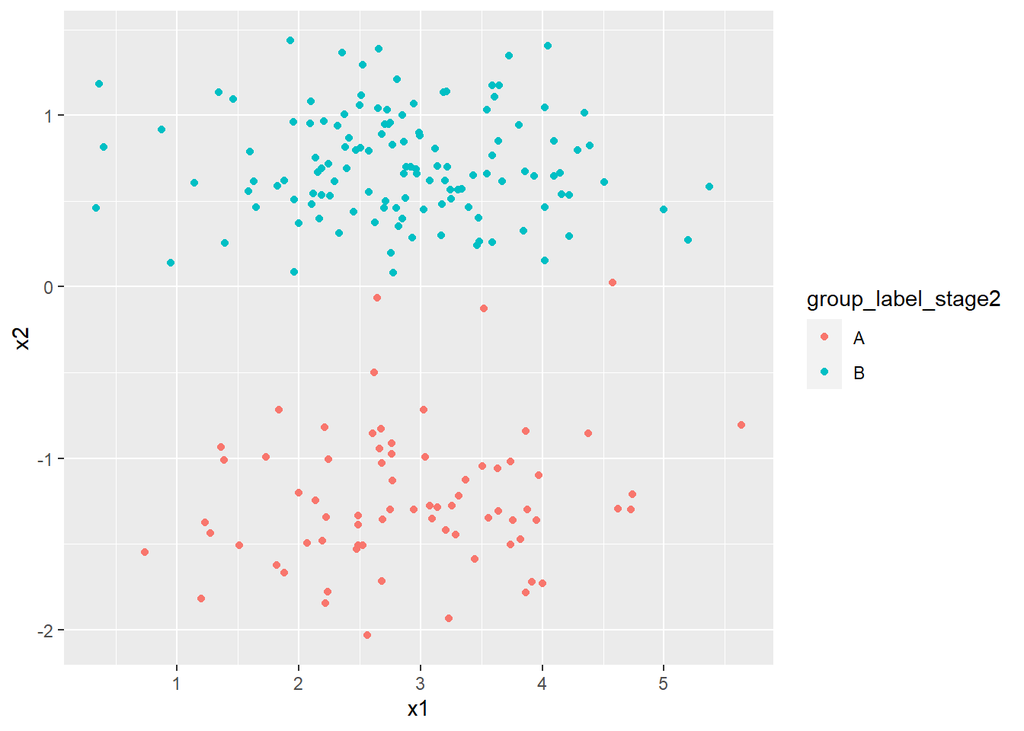

```r
library(ggplot2)

portfolio %>%
ggplot() +
  geom_point(
    aes(x1, x2, colour = group_label_stage2)
  )
```